# Analys first data

Awabousso

2024-04-02

# Analyse des données du 20240305

## Importation des données

Il faut se mettre dans le dossier où vous avez votre data

```r
library(readr)
library(openxlsx)
df  <- read_tsv("E:/stageAwa/first/firstdata/20240305_140028_410_MBJ_directDIA_test5_Report.tsv")
## affichage
#View(df)
```

### Importation de tous les library necessaire pour la suite de mes analyses

```r
library(FactoMineR) ## pour la PCA
library(gtsummary)## pour summary
library(mice)
library(tidyverse)
```

```r
library(tidyr)
library(preprocessCore)
library(pheatmap)
library(bestNormalize)#library(MSnSet.utils)
library(circlize) # colorRamp2
library(ComplexHeatmap) # additional modifications
```

[output not shown]

```r
library(dplyr) # %>%
library(ggpubr)
library(factoextra) ## Pour le clustering
library(openxlsx) ### pour les fichiers excel
library(DOSE)
```

```r
library(enrichplot)
library(Biobase)
library(fgsea)
library(clusterProfiler)
library(topGO)
library(Glimma)
library(limma)
library(openxlsx
        )
library(ComplexHeatmap)
#library(biomaRt)
library(dendextend)
```

## Modification des données car il y a la présence de NaN

Remplacer les NaN par NA pour faciliter l’analyse dans R

```r
# copie du data
df_bis <- df

### remplacer les NaN par NA
for (col in names(df_bis)[-1]) {
  df_bis[[col]] <- gsub(",", ".", as.character(df_bis[[col]]))
  df_bis[[col]] <- ifelse(df_bis[[col]] == "NaN", NA, df_bis[[col]])
}


# Convertir toutes les colonnes en format numérique
df_bis[] <- lapply(df_bis, as.numeric)
# Affichage
#View(df_bis)
```

## Mettre la première colonne (**PG.ProteinGroups**) en tant que nom des lignes

```r
# j'enléve la  premiére colonne
df_bis<-as.matrix(df_bis[,-1])
# Mettre la première colonne (**PG.ProteinGroups**) en tant que nom des lignes
rownames(df_bis)<-df$PG.ProteinGroups

# Affichage
#View(df_bis)
```

## Remplacer les NA par zéro pour faciliter la suite des analyses

- Mettre en log 2 les données s’ils ne sont pas logées
- On note la présence de -Inf apres la modification
- On remplace c’est -Inf à zéro

```r
#  Remplacer les Na par 0
df_bis[is.na(df_bis)] <- 0
# Mettre en log2 les données
dfbis_log2 <- log2(df_bis)
# Remplacer les valeurs -Inf par 0
dfbis_log2[is.infinite(dfbis_log2) & dfbis_log2 == -Inf] <- 0
```

## Decontamination des données et filtre des données

### **Nettoyage des données**

```r
# Créer une expression régulière pour les noms à supprimer
patterns <- c("^ENS", "^H-INV", "^REFSEQ")

# Créer un vecteur de booléens indiquant quelles lignes correspondent à ces motifs
rows_to_remove <- grepl(paste(patterns, collapse = "|"), rownames(dfbis_log2))

# Supprimer les lignes correspondantes
df_filtered <- dfbis_log2[!rows_to_remove, ]
#View(df_filtered)
dim(df_filtered)
```

```
## [1] 4800   16
```

### je supprime les Proteines groupes qui diffèrent de 1 ou 2 acides aminés, on a pas pu identifier le peptides qui entre les protéines.

je vais les enléver

```r
# Identifier les lignes à supprimer
rows_to_remove <- grepl("^[A-Z0-9]+(;[A-Z0-9]+)+$", rownames(df_filtered))

# Filtrer le dataframe
df_special <- df_filtered[rows_to_remove, ]
df_filtered <- df_filtered[!rows_to_remove, ]
dim(df_filtered)
```

```
## [1] 4699   16
```

```r
# Identifier les lignes contenant le motif spécifié
rows_to_remove <- grepl("^[A-Z0-9]+;[A-Z0-9]+-[0-9]$", rownames(df_filtered))

# Supprimer les lignes correspondantes
df_filtered <- df_filtered[!rows_to_remove, , drop = FALSE]

dim(df_filtered)  # Vérifiez les dimensions après avoir supprimé les lignes
```

```
## [1] 4697   16
```

```r
#View(df_filtered)

# Calculer la somme des valeurs de chaque ligne
row_sums <- rowSums(df_filtered)

# Identifier les lignes avec une somme égale à zéro
rows_to_remove <- row_sums == 0

# Supprimer les lignes avec une somme égale à zéro
df_filtered <- df_filtered[!rows_to_remove, ]
dim(df_filtered)
```

```
## [1] 4696   16
```

```r
df_filtered <- df_filtered[!(rownames(df_filtered) %in% c("A2AB72", "Q1RMK2")), ]
dim(df_filtered)
```

```
## [1] 4694   16
```

```r
#ss <- data.frame(ss = df_filtered)
#output_file1 <- "rchr.xlsx"
#ss <- round(ss,2)
# Écrire le dataframe dans le fichier Excel
#write.xlsx(ss, file = output_file1, rowNames = TRUE)
```

### suppression des Proteines non humaine

```r
# Charger la bibliothèque readxl
library(readxl)

# Chemin vers le fichier Excel sur votre ordinateur des données téléchargés en Uniprot online
chemin <- "E:/stageAwa/first/unip.xlsx"

# Lire le fichier Excel
donnees <- read_excel(chemin)
dim(donnees)
```

```
## [1] 4694    5
```

```r
#  Afficher les premières lignes du fichier pour vérifier l'importation
#View(donnees)
donnes <- as.matrix(donnees)
#View(donnees)
```

```r
# Copier df_filtered dans df_filtered_copy
df_filtered_copy <- df_filtered

#Changement des nom de lignes en organisme dans le fichier donnée
row.names(df_filtered_copy) <- donnees$E

#Suppression de toutes les lignes qui ne sont pas Homo sapiens
df_filtered_human <- subset(df_filtered_copy, row.names(df_filtered_copy) == "Homo sapiens (Human)")
dim(df_filtered_human)
```

```
## [1] 4614   16
```

```r
# Suppression des lignes qui ne sont pas Homo sapiens
donnees <- subset(donnees,donnees$E == "Homo sapiens (Human)")
dim(donnees)
```

```
## [1] 4614    5
```

```r
### Remettre les noms de lignes en Gènes
rownames(df_filtered_human)<- donnees$D

View(df_filtered_human)
# Écrire le dataframe dans le fichier Excel
#write.xlsx(aa, file = output_file1, rowNames = TRUE)

# Verification avant de lancer ce code  il faut bien regarder s'il y a des nom des lignes avec Na
which(is.na(row.names(df_filtered_human)))
```

```
## [1] 2663
```

```r
# Si c'est le cas regardé quel gène correspondant à cette ligne ou ces ligne et le(s) remplacer
rownames(df_filtered_human)[2663] <- "Q709F0"
which(is.na(row.names(df_filtered_human)))
```

```
## integer(0)
```

```r
#(df_filtered_copy)[2665]
#View(dfbis_log2)
```

## Filtrer les données par sous-ensemble puis qu’on a 3 groupes d’echantillons

- EJ10 ( post_implantatoire ) avec 5 pools
- PB ( blastocyste) avec 5 pools
- PM ( Morula) avec 6 pools

```r
# Trouver les colonnes contenant le terme "EJ10"
columns_to_keep <- grep("EJ10", colnames(df_filtered_human), value = TRUE)

# Sélectionner les colonnes correspondantes dans votre jeu de données
df_EJ10 <- df_filtered_human[, columns_to_keep]
### Trouver tous les colonnes contenant le terme "PB"
columns_to_keep <- grep("PB", colnames(df_filtered_human), value = TRUE)

# Sélectionner les colonnes correspondantes dans votre jeu de données
df_PB  <- df_filtered_human[, columns_to_keep]

### Trouver tous les colonnes contenant le terme "PB"  et "pools"
columns_to_keep <- grep("PM|Pool", colnames(df_filtered_human), value = TRUE)

# Sélectionner les colonnes correspondantes dans votre jeu de données
df_PM  <- df_filtered_human[, columns_to_keep]
```

## Distribution de la quantité de protéines dans chaque sous-ensemble

- EJ10 stade J10

```r
# Supprimer les lignes avec des zéros dans toutes les colonnes
df_EJ10t <- df_EJ10[rowSums(df_EJ10 == 0) == 0,]
dim(df_EJ10)
```

```
## [1] 4614    5
```

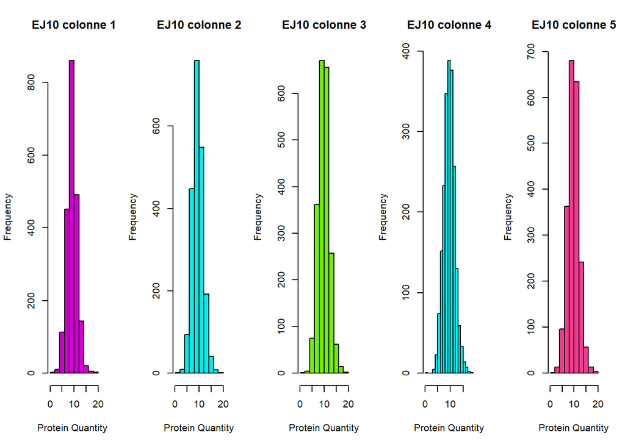

```r
# Créer un histogramme pour visualiser la distribution
par(mfrow = c(1, 5), bg="white")
hist(df_EJ10t[,1],breaks="Sturges",xlab="Protein Quantity ",ylab="Frequency",main=" EJ10 colonne 1 ",col = "magenta3")
hist(df_EJ10t[,2],breaks="Sturges",xlab="Protein Quantity",ylab="Frequency",main=" EJ10 colonne 2 ",col = "cyan2")
hist(df_EJ10t[,3],breaks="Sturges",xlab="Protein Quantity",ylab="Frequency",main=" EJ10 colonne 3 ",col = "chartreuse2")
hist(df_EJ10t[,4],breaks="Sturges",xlab="Protein Quantity",ylab="Frequency",main=" EJ10 colonne 4 ",col = "cyan1")
hist(df_EJ10t[,5],breaks="Sturges",xlab="Protein Quantity",ylab="Frequency",main=" EJ10 colonne 5 ",col="violetred2")
```

- PB stade Blastocyste

```r
# Supprimer les lignes avec des zéros dans toutes les colonnes
df_PBt <- df_PB[rowSums(df_PB == 0) == 0,]
dim(df_PB)
```

```
## [1] 4614    5
```

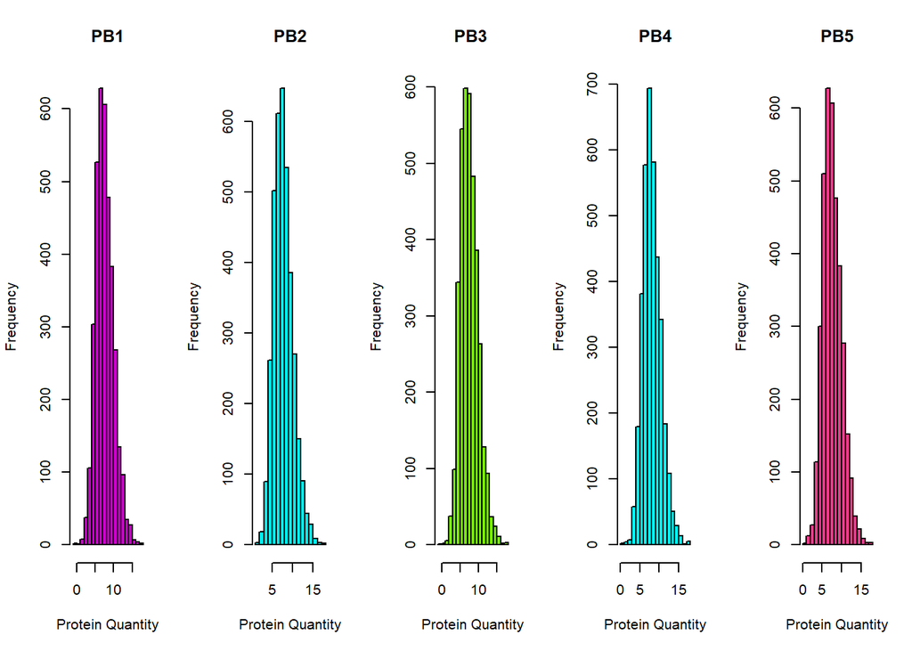

```r
# Créer un histogramme pour visualiser la distribution
par(mfrow = c(1, 5), bg="white")
hist(df_PBt[,1],breaks="Sturges",xlab="Protein Quantity",ylab="Frequency",main=" PB1 ",col = "magenta3")
hist(df_PBt[,2],breaks="Sturges",xlab="Protein Quantity",ylab="Frequency",main=" PB2 ",col = "cyan2")
hist(df_PBt[,3],breaks="Sturges",xlab="Protein Quantity",ylab="Frequency",main="PB3 ",col = "chartreuse2")
hist(df_PBt[,4],breaks="Sturges",xlab="Protein Quantity",ylab="Frequency",main=" PB4 ",col = "cyan1")
hist(df_PBt[,5],breaks="Sturges",xlab="Protein Quantity",ylab="Frequency",main=" PB5 ",col="violetred2")
```

- PM Morula

```r
# Supprimer les lignes avec des zéros dans toutes les colonnes
df_PMt <- df_PM[rowSums(df_PM== 0) == 0,]
dim(df_PM)
```

```
## [1] 4614    6
```

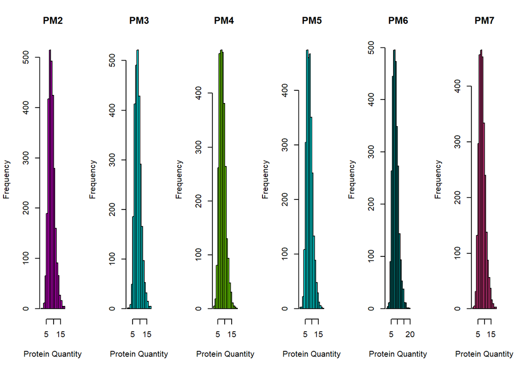

```r
# Créer un histogramme pour visualiser la distribution
par(mfrow = c(1, 6), bg="white")

hist(df_PMt[,1],breaks="Sturges",xlab="Protein Quantity",ylab="Frequency",main=" PM2 ",col = "magenta3")
hist(df_PMt[,2],breaks="Sturges",xlab="Protein Quantity",ylab="Frequency",main=" PM3 ",col = "cyan2")
hist(df_PMt[,3],breaks="Sturges",xlab="Protein Quantity",ylab="Frequency",main="PM4 ",col = "chartreuse2")
hist(df_PMt[,4],breaks="Sturges",xlab="Protein Quantity",ylab="Frequency",main=" PM5 ",col = "cyan1")
hist(df_PMt[,5],breaks="Sturges",xlab="Protein Quantity",ylab="Frequency",main=" PM6 ",col = "cyan4")
hist(df_PMt[,6],breaks="Sturges",xlab="Protein Quantity",ylab="Frequency",main=" PM7 ",col="violetred2")
```

## Pour les sous-ensemble on regarde il y a combien de proteines qui sont présentes 0/5 ainsi de suite

- EJ10 stade J10

```r
# Créer une copie du dataframe avec des valeurs binaires (1 si la valeur est différente de zéro, sinon 0)
df_binary <- df_EJ10!= 0

# Calculer le nombre de colonnes
num_columns <- ncol(df_binary)

# Calculer la somme des valeurs binaires pour chaque ligne
presence_counts <- rowSums(df_binary)
# Compter le nombre de protéines présentes dans chaque combinaison de colonnes
counts <- table(presence_counts)

# Afficher le résultat
print(counts)
```

```
## presence_counts
##    0    1    2    3    4    5
##  959  359  329  333  532 2102
```

- PB stade Blastocyste

```r
# Créer une copie du dataframe avec des valeurs binaires (1 si la valeur est différente de zéro, sinon 0)
df_binary <- df_PB != 0

# Calculer le nombre de colonnes
num_columns <- ncol(df_binary)

# Calculer la somme des valeurs binaires pour chaque ligne
presence_counts <- rowSums(df_binary)


# Compter le nombre de protéines présentes dans chaque combinaison de colonnes
counts <- table(presence_counts)

# Afficher le résultat
print(counts)
```

```
## presence_counts
##    0    1    2    3    4    5
##  142  109  107  181  420 3655
```

- PM Morula

```r
# Créer une copie du dataframe avec des valeurs binaires (1 si la valeur est différente de zéro, sinon 0)
df_binary <- df_PM != 0

# Calculer le nombre de colonnes
num_columns <- ncol(df_binary)

# Calculer la somme des valeurs binaires pour chaque ligne
presence_counts <- rowSums(df_binary)


# Compter le nombre de protéines présentes dans chaque combinaison de colonnes
counts <- table(presence_counts)

# Afficher le résultat
print(counts)
```

```
## presence_counts
##    0    1    2    3    4    5    6
##  288  246  236  265  310  504 2765
```

## Analyses 2 à 2 des sous groupes

- Les Protéines qui match entre deux échantillons
- Protéines matches entre EJ10 et PB

```r
# Calculer le nombre de valeurs n dans les cinq premières colonnes pour chaque ligne
a<-rowSums(df_EJ10[,1:5])
### Filtrer le dataframe pour ne conserver que les lignes avec au moins une valeur non nulle dans les cinq premières colonnes
EJ10filtered <- subset(df_EJ10, a > 0)
# Calculer le nombre de valeurs n dans les cinq premières colonnes pour chaque ligne
a<-rowSums(df_PB[,1:5])
### Filtrer le dataframe pour ne conserver que les lignes avec au moins une valeur non nulle dans les cinq premières colonnes
PBfiltered <- subset(df_PB, a > 0)
# Calculer le nombre de valeurs n dans les cinq premières colonnes pour chaque ligne
a<-rowSums(df_PM[,1:6])
### Filtrer le dataframe pour ne conserver que les lignes avec au moins une valeur non nulle dans les cinq premières colonnes
PMfiltered <- subset(df_PM, a > 0)



# Extraire les noms des protéines de chaque dataframe
proteins_df_EJ10 <- rownames(EJ10filtered)
proteins_df_PB <- rownames(PBfiltered)

#View(EJ10filtered)
# Trouver les protéines qui correspondent entre les deux dataframes
matching_proteins <- intersect(proteins_df_EJ10, proteins_df_PB)

#print(matching_proteins)

# Compter le nombre de protéines correspondantes
nombre_proteines_correspondantes <- length(matching_proteins)

# Afficher le nombre de protéines correspondantes
#print(nombre_proteines_correspondantes)

# Trouver les protéines présentes dans df_EJ10 mais absentes dans df_PB

proteins_only_in_EJ10 <- setdiff( proteins_df_EJ10,proteins_df_PB)
# Trouver les protéines présentes dans  df_PB mais absentes dans df_EJ10
proteins_only_in_PB<- setdiff(proteins_df_PB,proteins_df_EJ10)



#Compter le nombre de protéines présentes uniquement dans df_PB
print(length(proteins_only_in_EJ10))
```

```
## [1] 121
```

```r
#Compter le nombre de protéines présentes uniquement dans df_PM
print(length(proteins_only_in_PB))
```

```
## [1] 936
```

```r
# Calculer la moyenne des protéines uniques dans chaque échantillon
mean_EJ10 <- rowMeans(EJ10filtered[proteins_only_in_EJ10, ])
mean_EJ10 <- round(log2(mean_EJ10),2)
mean_EJ10 <- mean_EJ10[order(mean_EJ10,decreasing=FALSE)]
mean_PB <- rowMeans(PBfiltered[proteins_only_in_PB, ])

mean_PB <- round(log2(mean_PB),2)
mean_PB <- mean_PB[order(mean_PB,decreasing=FALSE)]

# Créer un dataframe contenant les moyennes
mean_df <- data.frame(Mean_EJ10 = mean_EJ10)

# Créer un dataframe contenant les moyennes
mean_df2 <- data.frame(mean_PB = mean_PB)
# Spécifier le nom du fichier Excel de sortie
output_file <- "PBvsEJ10_EJ10uniquemeans .xlsx"

# Spécifier le nom du fichier Excel de sortie
output_file1 <- "PBvsEJ10_PBuniquemeans .xlsx"

# Écrire le dataframe dans le fichier Excel
write.xlsx(mean_df, file = output_file, rowNames = TRUE)

# Écrire le dataframe dans le fichier Excel
write.xlsx(mean_df2, file = output_file1, rowNames = TRUE)
```

```r
# Extraire les noms des protéines de chaque dataframe
proteins_df_EJ10 <- rownames(EJ10filtered)
proteins_df_PM <- rownames(PMfiltered)


# Trouver les protéines qui correspondent entre les deux dataframes
matching_proteins <- intersect(proteins_df_EJ10, proteins_df_PM)

#print(matching_proteins)

# Compter le nombre de protéines correspondantes
nombre_proteines_correspondantes <- length(matching_proteins)

# Afficher le nombre de protéines correspondantes
#print(nombre_proteines_correspondantes)


proteins_only_in_EJ10 <- setdiff( proteins_df_EJ10,proteins_df_PM)

proteins_only_in_PM<- setdiff(proteins_df_PM,proteins_df_EJ10)

#Compter le nombre de protéines présentes uniquement dans df_PB
print(length(proteins_only_in_EJ10))
```

```
## [1] 217
```

```r
#Compter le nombre de protéines présentes uniquement dans df_PM
print(length(proteins_only_in_PM))
```

```
## [1] 886
```

```r
# Calculer la moyenne des protéines uniques dans chaque échantillon
mean_EJ10 <- rowMeans(EJ10filtered[proteins_only_in_EJ10, ])
mean_EJ10 <- round(log2(mean_EJ10),2)
mean_EJ10 <- mean_EJ10[order(mean_EJ10,decreasing=FALSE)]


# Créer un dataframe contenant les moyennes
mean_df <- data.frame(Mean_EJ10 = mean_EJ10)

# Spécifier le nom du fichier Excel de sortie
output_file <- "PMvsEJ10_EJ10uniquemeans .xlsx"

# Écrire le dataframe dans le fichier Excel
write.xlsx(mean_df, file = output_file, rowNames = TRUE)


# Calculer la moyenne des protéines uniques dans chaque échantillon
mean_PM <- rowMeans(PMfiltered[proteins_only_in_PM, ])

mean_PM <- round(log2(mean_PM),2)
mean_PM <- mean_PM[order(mean_PM,decreasing=FALSE)]
# Créer un dataframe contenant les moyennes
mean_df2 <- data.frame(Mean_PM = mean_PM)
# Spécifier le nom du fichier Excel de sortie
output_file1 <- "PMvsEJ10_PMuniquemeans .xlsx"
# Écrire le dataframe dans le fichier Excel
write.xlsx(mean_df2, file = output_file1, rowNames = TRUE)
```

## Analyses differentielle

- PCA Création d’une table de notation pour la suite de mes analyses sur les données

```r
samples <- c("[1]410_EJ10-test2_OT_Slot2-2_1_6949.d.PG.Quantity" , "[2]410_EJ10-test2_Slot2-2_1_6947.d.PG.Quantity",
 "[3]410_EJ10-test2_TClow_Slot2-3_1_6951.d.PG.Quantity" , "[4]410_EJ10-test5_TClow_Slot2-1_1_6953.d.PG.Quantity","[5]410_EJ10-test_Slot2-1_1_6944.d.PG.Quantity" ,"[6]404_PB1_Slot1-22_1_5701.d.PG.Quantity","[7]404_PB2_Slot1-16_1_5695.d.PG.Quantity" ,"[8]404_PB3_Slot1-14_1_5693.d.PG.Quantity","[9]404_PB4_Slot1-20_1_5699.d.PG.Quantity" ,"[10]404_PB5_Slot1-18_1_5697.d.PG.Quantity","[11]404_PM2_Slot1-15_1_5694.d.PG.Quantity" ,"[12]404_PM3_Slot1-17_1_5696.d.PG.Quantity"
,"[13]404_PM4_Slot1-19_1_5698.d.PG.Quantity"
, "[14]404_PM5_Slot1-21_1_5700.d.PG.Quantity"
, "[15]404_PM6_Slot1-23_1_5702.d.PG.Quantity"
,"[16]404_Poolx5MC_Slot1-33_1_5531.d.PG.Quantity" )
stades <- c("EJ10", "EJ10","EJ10","EJ10","EJ10","PB", "PB","PB","PB","PB","PM", "PM","PM","PM","PM","PM")

# Combinaison des deux vecteurs pour former une matrice avec deux colonnes
tblnot <- cbind(samples, stades)

# Spécifier le nom de votre fichier de sortie
output_file <- "tblnot.tsv"

# Écrire la matrice dans un fichier TSV
write.table(tblnot, file = output_file, sep = "\t", quote = FALSE, row.names = FALSE)
```

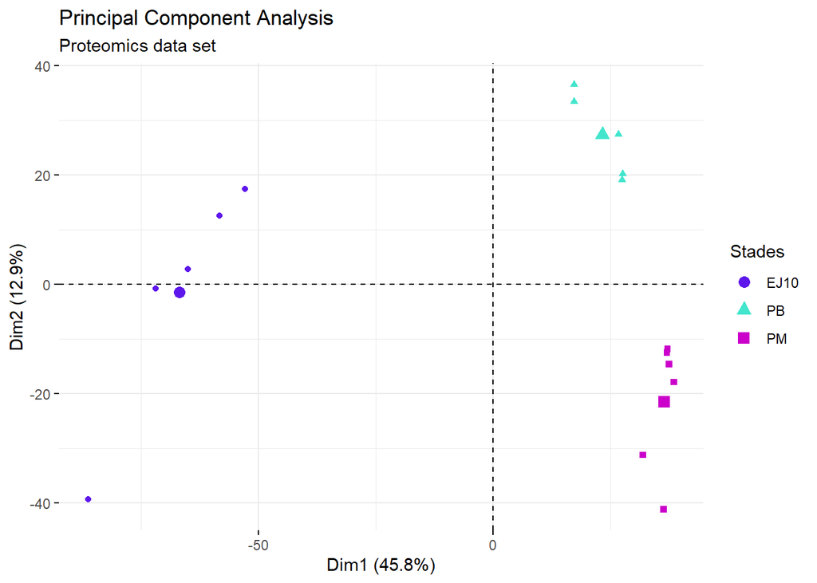

```r
library(FactoMineR)
library(RColorBrewer)
### pca resultat
#dfbis_log2
pca.res <- PCA(t(df_filtered_human),scale.unit = TRUE, ncp = 5, graph = FALSE)

# Total contribution on PC1 and PC2


my_colors <- c("EJ10" = "#5e17eb", "PB" = "#43e5cd", "PM" = "#cb01cb")

# Utiliser la palette de couleurs personnalisée dans le plot PCA
fviz_pca_ind(pca.res, geom = "point",
             col.ind = tblnot[, 2],
             palette = my_colors, repel = TRUE,addEllipses = FALSE, subtitle = "Proteomics data set", legend.title = "Stades",title = "Principal Component Analysis",col.ind.sup = "blue"
             )
```

- HeatMap

```
## `use_raster` is automatically set to TRUE for a matrix with more than
## 2000 rows. You can control `use_raster` argument by explicitly setting
## TRUE/FALSE to it.
##
## Set `ht_opt$message = FALSE` to turn off this message.
```

```
## 'magick' package is suggested to install to give better rasterization.
##
## Set `ht_opt$message = FALSE` to turn off this message.
```

[figure not shown]

```r
Heatmap(df_filtered_human)
```

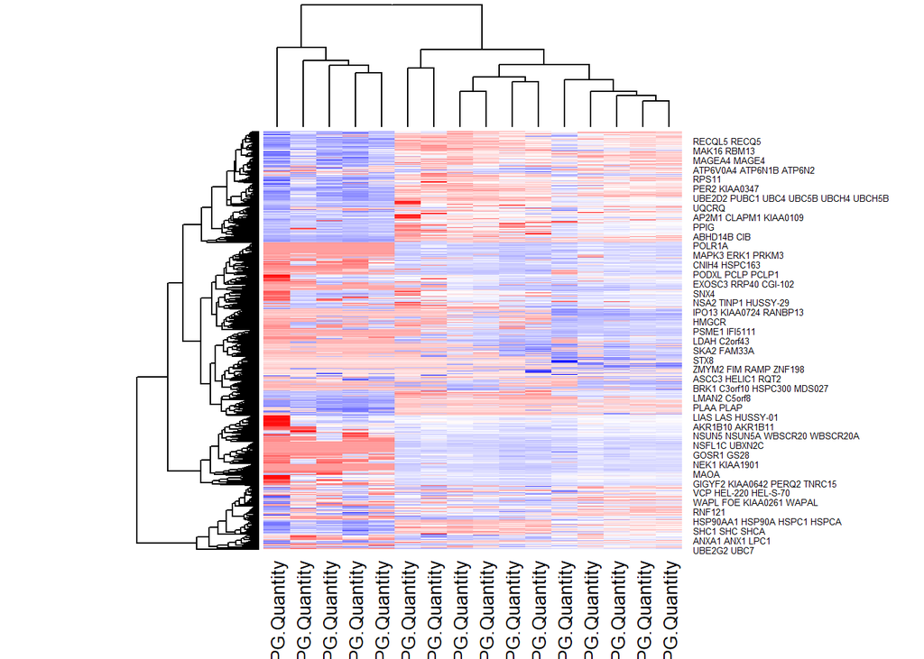

```r
### normal heatmap
col<- colorRampPalette(c("red", "white", "blue"))(256)
heatmap(df_filtered_human,scale='row',col=col )
```

## limma

### Test statistique pour une certaine proteine dans un certaine groupe (EJ10 ,PB,PM)

```r
# Créer une copie du dataframe avec les noms de lignes modifiés
df_filtered_clean <- df_filtered_human
# Modifier les noms de lignes pour ne garder que le premier nom
rownames(df_filtered_clean) <- sub(" .*", "", rownames(df_filtered_clean))

# Assurez-vous que la bibliothèque limma est installée et chargée
#install.packages("limma")
library(limma)
test <- round(df_filtered_clean,2)
#test[!is.finite(test)] <- 0
# Créez votre design matrix
design <- model.matrix(~ 0 + factor(tblnot[,2]),data=as.data.frame(test))
colnames(design) <- c ("EJ10","PB","PM")
contrasts <- makeContrasts(
  levels = colnames(design),
  EJ10_vs_PB = EJ10- PB
)

# Appliquez lmFit pour ajuster le modèle linéaire
fit <- lmFit(test, design)
fit<-eBayes(fit)

# Test de contraste
fit_contrast <- contrasts.fit(fit, contrasts)
fit_contrast <- eBayes(fit_contrast)
# Correction de la p-value
results <- decideTests(fit_contrast, method = 'global', p.value = 0.05, adjust.method = "fdr")

# Identification des protéines différentiellement exprimées
top_proteins <- topTable(fit_contrast, coef = "EJ10_vs_PB", adjust = "fdr", number = Inf)

# Afficher les résultats
#top_proteins
# Obtenez les résidus
residuals <- residuals(fit,test)

# Calculez les écarts-types des coefficients
coef_stdev <-fit$sigma
# Calculez les statistiques de test (t-statistics)
test_statistics <- coef(fit) / coef_stdev

# Déterminez les résultats des tests en fonction des seuils de significativité souhaités
threshold <- 1.96 # Pour un seuil de 5% (2-tailed) en utilisant la distribution normale standard
test_results <- abs(test_statistics) > threshold

# Afficher les résultats des tests
#View(test_results)
result_df <-  data.frame(EJ10 = test_results[,1])

result_df$PB <- test_results[, "PB"]
result_df$PM <- test_results[, "PM"]
# Définir le nom du fichier Excel de sortie
output_file <- "test_results.xlsx"

# Écrire les résultats dans le fichier Excel
write.xlsx(result_df, file = output_file, rowNames = TRUE)
```

### Visualisation des resultat volcano plot et MAplot avec EJ10 vs PB

```r
#if (!require("BiocManager", quietly = TRUE))
#    install.packages("BiocManager")

#BiocManager::install("Glimma")
library(Glimma)
# Créez votre design matrix
design <- model.matrix(~ 0 + factor(tblnot[,2]),data=as.data.frame(df_filtered_clean))
colnames(design) <- c ("EJ10","PB","PM")
contrasts <- makeContrasts(
  levels = colnames(design),
  EJ10_vs_PB = EJ10- PB
)

# Test de contraste
fit_contrast1 <- contrasts.fit(fit, contrasts)
fit_contrast1 <- eBayes(fit_contrast1)

glimmaMA(fit_contrast1,status.cols=c("#43e5cd", "grey", "#5e17eb"))
```

[interactive chart not shown]

```r
#volcanoplot(fit_contrast1,coef=1,names= "EJ10_vs_PB")
```

```r
glimmaVolcano(fit_contrast1,status.cols=c("#43e5cd", "grey", "#5e17eb"))
```

[interactive chart not shown]

### visualisation des resultat volcano plot avec PM vs PB

```r
# Créez votre design matrix
design <- model.matrix(~ 0 + factor(tblnot[,2]),data=as.data.frame(test))
colnames(design) <- c ("EJ10","PB","PM")
contrasts <- makeContrasts(
  levels = colnames(design),
  PM_vs_PB = PM- PB
)

# Test de contraste
fit_contrast2 <- contrasts.fit(fit, contrasts)
fit_contrast2 <- eBayes(fit_contrast2)


glimmaMA(fit_contrast2,status.cols=c("#43e5cd", "grey", "#cb01cb"))
```

[interactive chart not shown]

```r
glimmaVolcano(fit_contrast2,status.cols=c("#43e5cd", "grey", "#cb01cb"))
```

[interactive chart not shown]

### Identification des Proteines differentiellement exprimés

```r
results <- decideTests(fit_contrast1, method = 'global',
                       p.value = 0.01,
                       adjust.method = "fdr")
summary(results)
```

```
##        EJ10_vs_PB
## Down         1148
## NotSig       2568
## Up            898
```

```r
results1 <- decideTests(fit_contrast2, method = 'global',
                       p.value = 0.01,
                       adjust.method = "fdr")
```

```r
# Filtrer les gènes exprimés en PM
genes_PM <- rownames(results1)[results1[,1]== 1]

# Filtrer les gènes exprimés en PB
genes_PB <- rownames(results1)[results1[,1]== -1]


# Filtrer les lignes correspondantes aux gènes exprimés en PM
df_PM_exp <- df_filtered_human[rownames(df_filtered_human) %in% genes_PM, ]
#View(df_PM_exp )



# Filtrer les lignes correspondantes aux gènes exprimés en PB
df_PB_exp <-df_filtered_human[rownames(df_filtered_human) %in% genes_PB, ]
#View(df_PB_exp )
```

## GO terms analysis

```r
library(topGO)
library(org.Hs.eg.db)
#if (!requireNamespace("BiocManager",quietly=TRUE))
#  install.packages("BiocManager")
#BiocManager::install()

gene_list <- rownames(df_filtered_human)
go_r <- enrichGO(gene = gene_list,
                      OrgDb = org.Hs.eg.db,  # Base de données pour l'organisme d'intérêt, ici Homo sapiens
                      ont = "CC",            # Aspect biologique de GO, BP pour Biological Process, MF pour Molecular Function, CC pour Cellular Component
                 keyType = "SYMBOL",
                      pAdjustMethod = "fdr", # Méthode d'ajustement pour les p-values
                      pvalueCutoff = 0.05)
ggo <- go_r
head(ggo)
```

```
##                    ID             Description GeneRatio   BgRatio       pvalue
## GO:0044391 GO:0044391       ribosomal subunit   64/1129 188/19886 5.430125e-33
## GO:0022626 GO:0022626      cytosolic ribosome   51/1129 118/19886 2.061173e-32
## GO:0005759 GO:0005759    mitochondrial matrix  103/1129 487/19886 4.009537e-32
## GO:0005840 GO:0005840                ribosome   68/1129 246/19886 9.380040e-29
## GO:0015934 GO:0015934 large ribosomal subunit   42/1129 117/19886 4.187275e-23
## GO:1990204 GO:1990204  oxidoreductase complex   43/1129 128/19886 2.634466e-22
##                p.adjust       qvalue
## GO:0044391 3.388398e-30 2.234925e-30
## GO:0022626 6.430859e-30 4.241676e-30
## GO:0005759 8.339837e-30 5.500803e-30
## GO:0005840 1.463286e-26 9.651567e-27
## GO:0015934 5.225719e-21 3.446788e-21
## GO:1990204 2.739844e-20 1.807151e-20
##                                                                                                                                                                                                                                                                                                          …
## GO:0044391                                                                                                                                                                                                                MRPS14/RPLP0/RPL7/RPL17/RPS12/RPL12/RPL22/RPS19/RPL13A/RPL35…
## GO:0022626                                                                                                                                                                                                                                                                                               …
## GO:0005759 LIPT2/TK2/NDUFS8/POLRMT/NDUFAB1/BCKDK/IDH3B/MRPS14/NDUFS7/ND…
## GO:0005840                                                                                                                                                                                      MRPS14/APOD/RPLP0/RPL7/RPL17/RPS12/RPL12/RPL22/RPS19/RPL13A/…
## GO:0015934                                                                                                                                                                                                                                                                                               …
## GO:1990204                                                                                                                                                                                                                                                                                               …
##            Count
## GO:0044391    64
## GO:0022626    51
## GO:0005759   103
## GO:0005840    68
## GO:0015934    42
## GO:1990204    43
```

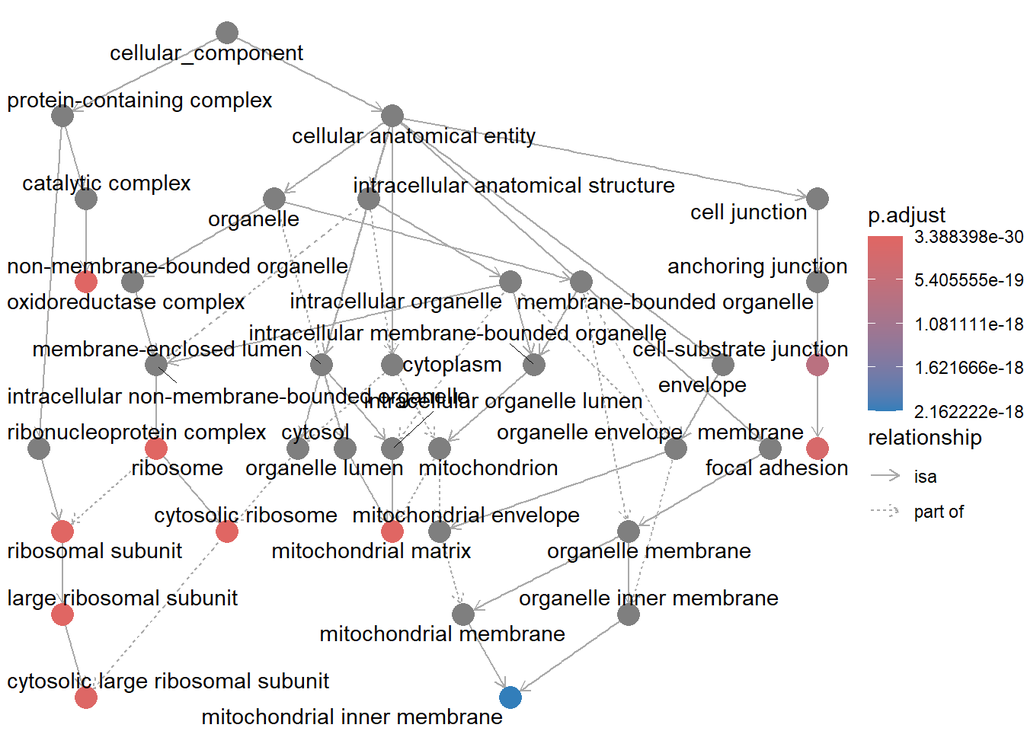

```r
goplot(ggo)
```

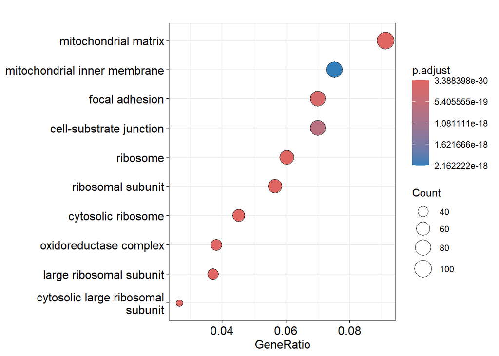

```r
dotplot(ggo)
```

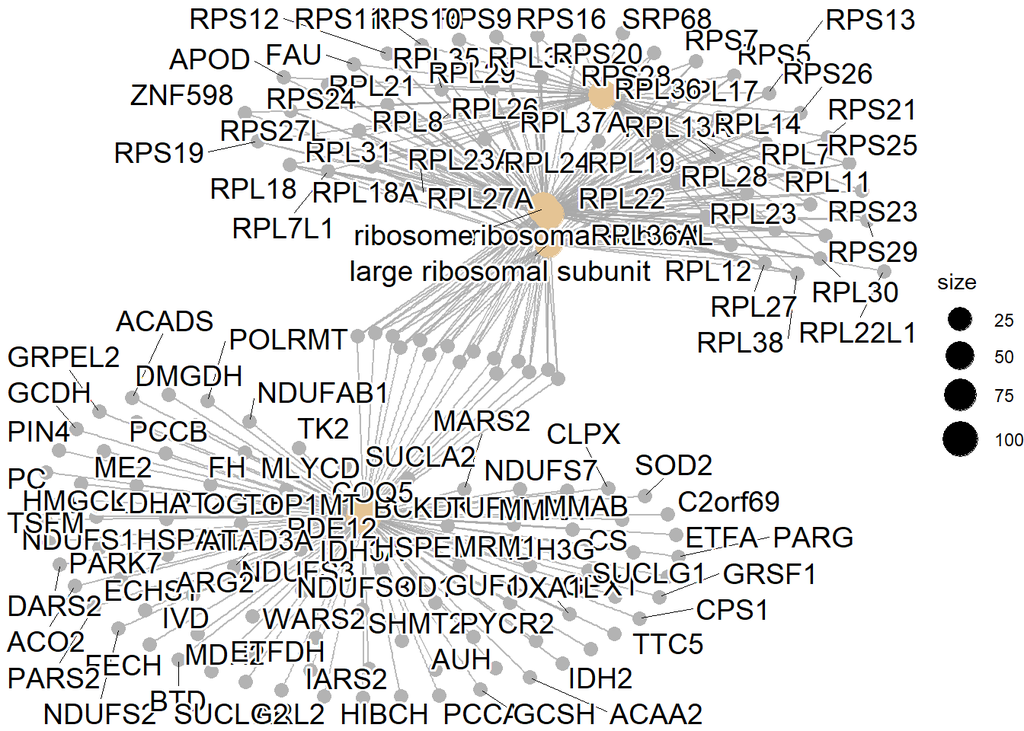

```r
cnetplot(ggo)
```

```r
#cnetplot(ggo, circular = TRUE, colorEdge = TRUE, foldChange=gene_list)
```

### GO sur les gènes differentiellement exprimés

#### Cycle de krebs

```r
# Créer une copie du dataframe avec les noms de lignes modifiés
df_filtered_clean <- df_filtered_human

### Modification des noms de colonnes
colnames(df_filtered_clean)<-c("J101","J102","J103","J104","J105","PB1","PB2","PB3","PB4","PB5","PM2","PM3","PM4","PM5","PM6","PM7")
colnames(df_filtered_clean)
```

```
##  [1] "J101" "J102" "J103" "J104" "J105" "PB1"  "PB2"  "PB3"  "PB4"  "PB5"
## [11] "PM2"  "PM3"  "PM4"  "PM5"  "PM6"  "PM7"
```

```r
# Modifier les noms de lignes pour ne garder que le premier nom
rownames(df_filtered_clean) <- sub(" .*", "", rownames(df_filtered_clean))

# Afficher les premières lignes du dataframe avec les noms de lignes modifiés
#View(df_filtered_clean)

# Liste des gènes à rechercher
genes_to_search <- c("CS", "IDH3A", "SUCLG2", "DLST", "OGDH", "SDHA", "SDHB", "SDHD", "SDHCCHAT", "DLD", "FH", "MDH2","IDH2","ACO2","SUCLG1","SUCLA2","IDH3B","IDH3G")

# Création d'un nouveau dataframe vide
dataframe_krebs <- data.frame()

# Parcours de chaque gène dans la liste
for (gene in genes_to_search) {
  # Vérification si le gène est présent dans les noms de lignes des données
  if (gene %in% rownames(df_filtered_clean)) {
    # Si le gène est présent, le récupérer et l'ajouter au nouveau dataframe
    dataframe_krebs <- rbind(dataframe_krebs, df_filtered_clean[gene, , drop = FALSE])
  }
}

# Afficher le nouveau dataframe contenant les gènes trouvés dans les données
#View(dataframe_krebs)
```

#### facteur de transcription

```r
# Importer le fichier avec tout les Facteurs de Transcription
chemin <- "E:/stageAwa/first/TF.xlsx"

# Lire le fichier Excel
TF <- read_excel(chemin)
TF
```

```
## # A tibble: 1,797 × 1
##    TF
##    <chr>
##  1 A1CF
##  2 ABCF2
##  3 ABL1
##  4 ACAA1
##  5 ACO1
##  6 ADARB1
##  7 ADNP
##  8 ADNP2
##  9 AEBP2
## 10 AFF4
## # ℹ 1,787 more rows
```

```r
#Modification des nom de lignes
row.names(TF) <- TF$TF
# Stocker dans une variable les Facteurs de Transcriptions
genes_find <- row.names(TF)

# Data frame
dataframe_TF <- data.frame()

# Parcours de chaque gène dans la liste
for (gene in genes_find) {
  # Vérification si le gène est présent dans les noms de lignes des données
  if (gene %in% rownames(df_filtered_clean)) {
    # Si le gène est présent, le récupérer et l'ajouter au nouveau dataframe
    dataframe_TF <- rbind(dataframe_TF, df_filtered_clean[gene, , drop = FALSE])
  }
}


# Affichage
# View(dataframe_TF)
```

#### kinase

```r
#  Importer le fichier avec tout les Kinases
chemin <- "E:/stageAwa/first/firstdata/kinome.xlsx"

# Lire le fichier Excel
kinome <- read_excel(chemin)

# Stockage de la liste des kinases
genes_find <- kinome$`HGNC Name`

dataframe_KN <- data.frame()
# Parcours de chaque gène dans la liste
for (gene in genes_find) {
  # Vérification si le gène est présent dans les noms de lignes des données
  if (gene %in% rownames(df_filtered_clean)) {
    # Si le gène est présent, le récupérer et l'ajouter au nouveau dataframe
    dataframe_KN <- rbind(dataframe_KN, df_filtered_clean[gene, , drop = FALSE])
  }
}


# Affichage
#View(dataframe_KN)
```

Cette partie est réalisèe pour avoir le nom des génes que je vais utiliser dans https://sparql.wikipathways.org/sparql/ pour la liste de gènes des voies qui m’intérèssent. Le code à lancer est dans un dossier nommer sparql.

```r
#Modifaction de la liste genes en un format qui marche avec le package Clusterprofiler
g <-bitr(gene_list
     , fromType = "SYMBOL", toType = "ENTREZID", OrgDb = org.Hs.eg.db)
# Enrichement avec Wikipathways
t <- enrichWP(g$ENTREZID , organism = "Homo sapiens")
# Transformation des résultats en data fram
t <- data.frame(t)
```

### Ribosomal

```r
#  Importer le fichier avec tout les gènes Ribosomales
chemin <- "E:/stageAwa/first/firstdata/Ribosomal.csv"
# Lire le fichier
ribosome <- read_csv(chemin)
# Stockage
genes_find <- ribosome$geneProduct

dataframe_Ribosome <- data.frame()
# Parcours de chaque gène dans la liste
for (gene in genes_find) {
  # Vérification si le gène est présent dans les noms de lignes des données
  if (gene %in% rownames(df_filtered_clean)) {
    # Si le gène est présent, le récupérer et l'ajouter au nouveau dataframe
    dataframe_Ribosome <- rbind(dataframe_Ribosome, df_filtered_clean[gene, , drop = FALSE])
  }
}
# Affichage
#View(dataframe_Ribosome)
```

### Phosphorylation et ses complexes

```r
#  Importer le fichier avec tout les gènes Ribosomales
chemin <- "E:/stageAwa/first/firstdata/liste_gene_mitochondrie/genes_order.tsv"
# Lire le fichier
phospho <- read_tsv(chemin)
# Stockage
genes_find <- phospho$genes

dataframe_phospho <- data.frame()
# Parcours de chaque gène dans la liste
for (gene in genes_find) {
  # Vérification si le gène est présent dans les noms de lignes des données
  if (gene %in% rownames(df_filtered_clean)) {
    # Si le gène est présent, le récupérer et l'ajouter au nouveau dataframe
   dataframe_phospho <- rbind(dataframe_phospho, df_filtered_clean[gene, , drop = FALSE])
  }
}
# Affichage
#View(dataframe_phospho)



# Importer gene order pour faire les complexes
#  Importer le fichier avec tout les gènes Ribosomales
chemin <- "E:/stageAwa/first/firstdata/liste_gene_mitochondrie/genes_order.tsv"
# Lire le fichier
gene_order <- read_tsv(chemin)
# Séparer les données en groupes en fonction de la colonne "modules"
module_groups <- split(gene_order$genes, gene_order$modules)
module_groups
```

```
## $`Complex 1`
##  [1] "NDUFV3"  "NDUFS2"  "NDUFS4"  "NDUFC2"  "NDUFA9"  "NDUFA5"  "NDUFS5"
##  [8] "NDUFA2"  "NDUFB5"  "NDUFA6"  "NDUFB9"  "NDUFA12" "NDUFA13" "NDUFA11"
## [15] "NDUFS1"  "NDUFB6"  "NDUFV2"  "NDUFB4"  "NDUFA7"  "NDUFC1"  "NDUFA3"
## [22] "NDUFB1"  "NDUFB3"  "NDUFA10" "NDUFB8"  "NDUFS8"  "NDUFS7"  "NDUFV1"
## [29] "NDUFB11" "NDUFA4"  "NDUFS6"  "NDUFB10" "NDUFAB1" "NDUFS3"  "NDUFA8"
## [36] "NDUFB7"
##
## $`Complex 2`
## [1] "SDHA" "SDHD" "SDHB" "SDHC"
##
## $`Complex 3`
## [1] "UQCRC1"  "CYC1"    "UQCRFS1" "UQCRH"   "UQCRQ"   "UQCRC2"  "UQCRB"
##
## $`Complex 4`
##  [1] "COX15"   "COX7C"   "COX7A2L" "COX8A"   "COX17"   "COX7B"   "COX7A2"
##  [8] "COX6C"   "COX6A1"  "COX4I1"  "COX6B1"  "COX10"   "COX5A"   "COX5B"
## [15] "COX11"
##
## $`Complex 5`
##  [1] "ATP6V1B1" "ATP12A"   "ATP6V0A2" "ATP6V1G2" "PPA1"     "ATP6V1H"
##  [7] "ATP6V1D"  "ATP6V0C"  "ATP6V1B2" "ATP6AP1"  "ATP6V1A"  "ATP6V1F"
## [13] "ATP6V1G1" "ATP6V0D1" "ATP6V1E1" "ATP6V0A1" "ATP6V1C1" "ATP6V1C2"
## [19] "ATP6V0A4"
```

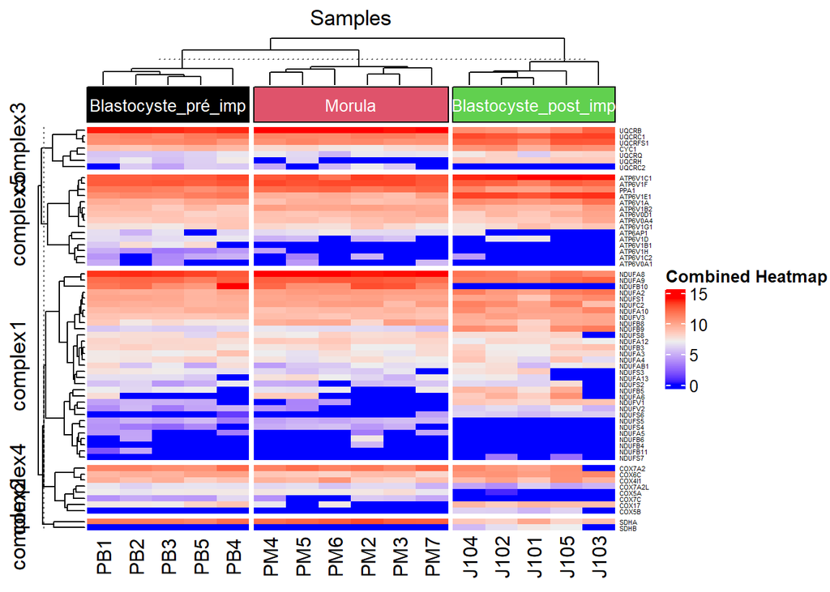

```r
# Afficher les premiers éléments de chaque groupe
complex1 <- module_groups$`Complex 1`
complex2 <- module_groups$`Complex 2`
complex3 <- module_groups$`Complex 3`
complex4 <- module_groups$`Complex 4`
complex5 <- module_groups$`Complex 5`
## creation des dataframe

df_complex1 <-data.frame()
df_complex2 <-data.frame()
df_complex3 <-data.frame()
df_complex4 <-data.frame()
df_complex5 <-data.frame()
# Parcours de chaque gène dans la liste
## Complex1
for (gene in complex1) {
  # Vérification si le gène est présent dans les noms de lignes des données
  if (gene %in% rownames(df_filtered_clean)) {
    # Si le gène est présent, le récupérer et l'ajouter au nouveau dataframe
   df_complex1 <- rbind(df_complex1, df_filtered_clean[gene, , drop = FALSE])
  }
}
## Complex2
for (gene in complex2) {
  # Vérification si le gène est présent dans les noms de lignes des données
  if (gene %in% rownames(df_filtered_clean)) {
    # Si le gène est présent, le récupérer et l'ajouter au nouveau dataframe
   df_complex2 <- rbind(df_complex2, df_filtered_clean[gene, , drop = FALSE])
  }
}

## complex3
for (gene in complex3) {
  # Vérification si le gène est présent dans les noms de lignes des données
  if (gene %in% rownames(df_filtered_clean)) {
    # Si le gène est présent, le récupérer et l'ajouter au nouveau dataframe
   df_complex3 <- rbind(df_complex3, df_filtered_clean[gene, , drop = FALSE])
  }
}
## Complex4
for (gene in complex4) {
  # Vérification si le gène est présent dans les noms de lignes des données
  if (gene %in% rownames(df_filtered_clean)) {
    # Si le gène est présent, le récupérer et l'ajouter au nouveau dataframe
   df_complex4 <- rbind(df_complex4, df_filtered_clean[gene, , drop = FALSE])
  }
}
## Complex5
for (gene in complex5) {
  # Vérification si le gène est présent dans les noms de lignes des données
  if (gene %in% rownames(df_filtered_clean)) {
    # Si le gène est présent, le récupérer et l'ajouter au nouveau dataframe
   df_complex5 <- rbind(df_complex5, df_filtered_clean[gene, , drop = FALSE])
  }
}

### complexHeatmap

heatmap11 <- Heatmap(df_complex1, name = "complex1")
heatmap22 <- Heatmap(df_complex2, name = "complex2")
heatmap33 <- Heatmap(df_complex3, name = "complex3")
heatmap44 <- Heatmap(df_complex4, name = "complex4")
heatmap55 <- Heatmap(df_complex5, name = "complex5")
data_heatmap11 <- (heatmap11@matrix)
data_heatmap22 <- (heatmap22@matrix)
data_heatmap33 <- (heatmap33@matrix)
data_heatmap44 <- (heatmap44@matrix)
data_heatmap55 <- (heatmap55@matrix)

# Combinaison des données
combined_data <- rbind(data_heatmap11,data_heatmap22,data_heatmap33,data_heatmap44,data_heatmap55)

############ Heatmap##########################


new_heatmap0<- Heatmap(combined_data, name = "Combined Heatmap",show_heatmap_legend = T,column_names_centered = TRUE,column_title = 'Samples',top_annotation = HeatmapAnnotation(foo = anno_block(gp = gpar(fill = 1:3),
        labels = c("Blastocyste_pré_imp", "Morula", "Blastocyste_post_imp"),
        labels_gp = gpar(col = "white", fontsize = 10))),
        row_split = rep(c("complex1", "complex2", "complex3","complex4","complex5"), c(nrow(data_heatmap11),nrow(data_heatmap22), nrow(data_heatmap33),nrow(data_heatmap44),nrow(data_heatmap55))),row_names_gp = gpar(fontsize = 4),column_km = 3 )


draw(new_heatmap0)
```

### Mitochondrial complex III assembly

```r
#  Importer le fichier avec tout les gènes Ribosomales
chemin <- "E:/stageAwa/first/firstdata/MitcomplexIII.csv"
# Lire le fichier
MitcomplexIII <- read_csv(chemin)
# Stockage
genes_find <- MitcomplexIII$geneProduct

dataframe_MitcomplexIII <- data.frame()
# Parcours de chaque gène dans la liste
for (gene in genes_find) {
  # Vérification si le gène est présent dans les noms de lignes des données
  if (gene %in% rownames(df_filtered_clean)) {
    # Si le gène est présent, le récupérer et l'ajouter au nouveau dataframe
   dataframe_MitcomplexIII <- rbind(dataframe_MitcomplexIII, df_filtered_clean[gene, , drop = FALSE])
  }
}
# Affichage
#View(dataframe_MitcomplexIII)
```

### Glycolysis and gluconeogenesis

```r
#  Importer le fichier avec tout les gènes Ribosomales
chemin <- "E:/stageAwa/first/firstdata/Glycolandgluco.csv"
# Lire le fichier
Glycolandgluco <- read_csv(chemin)
# Stockage
genes_find <- Glycolandgluco$geneProduct

dataframe_Glycolandgluco <- data.frame()
# Parcours de chaque gène dans la liste
for (gene in genes_find) {
  # Vérification si le gène est présent dans les noms de lignes des données
  if (gene %in% rownames(df_filtered_clean)) {
    # Si le gène est présent, le récupérer et l'ajouter au nouveau dataframe
   dataframe_Glycolandgluco <- rbind(dataframe_Glycolandgluco, df_filtered_clean[gene, , drop = FALSE])
  }
}
# Affichage
#View(dataframe_Glycolandgluco)
```

### Pre-implantation embryo (WP3527)

Les proteines de la voie Pre-implantation embryo

```r
#  Importer le fichier avec tout les gènes Pre-implantation embryo
chemin <- "E:/stageAwa/first/firstdata/pre_impl_embryo.csv"
# Lire le fichier
pre_im <- read_csv(chemin)
gene_find <- pre_im$geneProduct

# Création d'un nouveau dataframe vide
dataframe_pre_im <- data.frame()

# Parcours de chaque gène dans la liste
for (gene in gene_find) {
  # Vérification si le gène est présent dans les noms de lignes des données
  if (gene %in% rownames(df_filtered_clean)) {
    # Si le gène est présent, le récupérer et l'ajouter au nouveau dataframe
    dataframe_pre_im <- rbind(dataframe_pre_im, df_filtered_clean[gene, , drop = FALSE])
  }
}
View(dataframe_pre_im)
```

### DNA Methylation

```r
#  Importer le fichier avec tout les gènes DNA Methylation
chemin <- "E:/stageAwa/first/firstdata/DNA_methylation.tsv"
# Lire le fichier
Methyla <- read_tsv(chemin)
gene_find <- Methyla$Gene

# Création d'un nouveau dataframe vide
dataframe_Methyla <- data.frame()

# Parcours de chaque gène dans la liste
for (gene in gene_find) {
  # Vérification si le gène est présent dans les noms de lignes des données
  if (gene %in% rownames(df_filtered_clean)) {
    # Si le gène est présent, le récupérer et l'ajouter au nouveau dataframe
    dataframe_Methyla <- rbind(dataframe_Methyla, df_filtered_clean[gene, , drop = FALSE])
  }
}
#dataframe_Methyla
```

### DNA Binding

ATlas Human Protein

```r
#  Importer le fichier avec tout les gènes DNA_binding
chemin <- "E:/stageAwa/first/firstdata/DNA_binding.tsv"
# Lire le fichier
DNA_binding <- read_tsv(chemin)
gene_find <- DNA_binding$Gene

# Création d'un nouveau dataframe vide
dataframe_DNA_binding <- data.frame()

# Parcours de chaque gène dans la liste
for (gene in gene_find) {
  # Vérification si le gène est présent dans les noms de lignes des données
  if (gene %in% rownames(df_filtered_clean)) {
    # Si le gène est présent, le récupérer et l'ajouter au nouveau dataframe
    dataframe_DNA_binding <- rbind(dataframe_DNA_binding, df_filtered_clean[gene, , drop = FALSE])
  }
}
#dataframe_DNA_binding
```

ATlas Human Protein

```r
#  Importer le fichier avec tout les gènes epigenetic
chemin <- "E:/stageAwa/first/firstdata/epigenetic.tsv"
# Lire le fichier
epigenetic <- read_tsv(chemin)
gene_find <- epigenetic$Gene
# Création d'un nouveau dataframe vide
dataframe_epigenetic <- data.frame()

# Parcours de chaque gène dans la liste
for (gene in gene_find) {
  # Vérification si le gène est présent dans les noms de lignes des données
  if (gene %in% rownames(df_filtered_clean)) {
    # Si le gène est présent, le récupérer et l'ajouter au nouveau dataframe
    dataframe_epigenetic <- rbind(dataframe_epigenetic, df_filtered_clean[gene, , drop = FALSE])
  }
}
#dataframe_DNA_binding
```

### Fatty acid metabolism

```r
#  Importer le fichier avec tout les gènes epigenetic
chemin <- "E:/stageAwa/first/firstdata/fatty.tsv"
# Lire le fichier
fatty <- read_tsv(chemin)
gene_find <- fatty$Gene
# Création d'un nouveau dataframe vide
dataframe_fatty <- data.frame()

# Parcours de chaque gène dans la liste
for (gene in gene_find) {
  # Vérification si le gène est présent dans les noms de lignes des données
  if (gene %in% rownames(df_filtered_clean)) {
    # Si le gène est présent, le récupérer et l'ajouter au nouveau dataframe
   dataframe_fatty  <- rbind(dataframe_fatty , df_filtered_clean[gene, , drop = FALSE])
  }
}
# Affichage
View(dataframe_fatty)
```

### Un complexHeatmap pour les voies au dessus

```r
# Création des Heatmaps
heatmap1 <- Heatmap(dataframe_KN, name = "kinome",row_names_gp = gpar(fontsize = 4.5))
heatmap2 <- Heatmap(dataframe_krebs, name = "krebs")
heatmap3 <- Heatmap(dataframe_TF, name = "TF",row_names_gp = gpar(fontsize = 1.5))
heatmap4 <- Heatmap(dataframe_Ribosome, name = "Ribosomal",row_names_gp = gpar(fontsize = 5))
heatmap5 <- Heatmap(dataframe_phospho, name = "Oxidation phosphorylation")
heatmap6 <- Heatmap(dataframe_MitcomplexIII, name = "MitcomplexIII")
heatmap7 <- Heatmap(dataframe_Glycolandgluco, name = "Glycolysis and gluconeogenesis")
heatmap8 <- Heatmap(dataframe_pre_im, name = "Pre-implantation embryo (WP3527)
")
heatmap9 <- Heatmap(dataframe_Methyla, name = "Methylation",row_names_gp = gpar(fontsize = 5))
heatmap10 <- Heatmap(dataframe_DNA_binding, name = "DNA_binding",row_names_gp = gpar(fontsize = 5))
heatmap11 <- Heatmap(dataframe_epigenetic, name = "epigenetic",row_names_gp = gpar(fontsize = 5))
heatmap12 <- Heatmap(dataframe_fatty, name = "fatty_acid_metabolism",row_names_gp = gpar(fontsize = 4))
############ Lecture des heatmap et leur sauvegarde #####################

# Création du dossier pour stocker le PDF
dir.create("output_directory")
# Chemin complet du fichier PDF
pdf_file <- file.path("output_directory", "HMpathways.pdf")

# Ouvrir un fichier PDF
pdf(pdf_file)

# Dessiner le Heatmap dans le fichier PDF
heatmap1
heatmap2
heatmap3
heatmap4
heatmap5
heatmap6
heatmap7
heatmap8
heatmap9
heatmap10
heatmap11
heatmap12

# Fermer le fichier PDF
dev.off()
```

```r
# Extraction des données des heatmaps
data_heatmap1 <- (heatmap1@matrix)
data_heatmap2 <- (heatmap2@matrix)
data_heatmap3 <- (heatmap3@matrix)

data_heatmap4 <- (heatmap4@matrix)
colnames(df_filtered_clean)
```

```
##  [1] "J101" "J102" "J103" "J104" "J105" "PB1"  "PB2"  "PB3"  "PB4"  "PB5"
## [11] "PM2"  "PM3"  "PM4"  "PM5"  "PM6"  "PM7"
```

```r
# Combinaison des données
combined_data <- rbind(data_heatmap1,data_heatmap2,data_heatmap3)

# Création d'un nouveau objet Heatmap avec les données combinées

row_dend = hclust(dist(combined_data)) # row clustering
col_dend = hclust(dist(t(combined_data))) # column clustering

new_heatmap <- Heatmap(combined_data, name = "Combined Heatmap",show_heatmap_legend = T,column_names_centered = TRUE,column_title = 'Samples',
        row_split = rep(c("Kinone", "Krebs", "TF"), c(nrow(data_heatmap1),nrow(data_heatmap2), nrow(data_heatmap3))), cluster_columns = color_branches(col_dend, k = 3),row_names_gp = gpar(fontsize = 2.5))


# Chemin complet du fichier PDF
pdf_file <- file.path("output_directory", "FT_Kinome_Krebs.pdf")

# Ouvrir un fichier PDF
pdf(pdf_file)

# Dessiner le Heatmap dans le fichier PDF
draw(new_heatmap)

# Fermer le fichier PDF
dev.off()
```

```r
###A mettre pour voir le nom Après avoir imprimé la Heatmap, vous pouvez obtenir la liste réelle des noms de lignes en lancant ce code apres la heatmap
#row.names(dataframe_krebs)[ row_order(heatmap2)]
#grid::grid.get(grep('text', grid::grid.ls(print = FALSE)[1]$name,value = TRUE)[1])[[1]]
```

### the pathways in the Metabolic Atlas

réalisation de tous les Heatmap de ces voies et Réaliser un complexe Heatmap

```r
chemins <- c(
             "pathway_AcylCoA.tsv",
             "pathway_Acylglycerides.tsv",
             "pathway_Alanine_.tsv",
             "pathway_Amino.tsv",
             "pathway_AminoacyltRNA.tsv",
             "pathway_Androgen.tsv",
             "pathway_Arachidonic.tsv",
             "pathway_Arginine.tsv",
             "pathway_Ascorbate.tsv",
             "pathway_BetaOCIFAM.tsv",
             "pathway_BetaUNSFAM.tsv",
             "pathway_Bileab.tsv",
             "pathway_Bilear.tsv",
             "pathway_Biopterin.tsv",
             "pathway_Biotin.tsv",
             "pathway_Blood.tsv",
             "pathway_Boefam.tsv",
             "pathway_Boefap.tsv",
             "pathway_Boofam.tsv",
             "pathway_Bopap.tsv",
             "pathway_Bopufam.tsv",
             "pathway_Boufa9m.tsv",
             "pathway_Boufap.tsv",
             "pathway_Bounfa9p.tsv",
             "pathway_Bounfap.tsv",
             "pathway_Butanoate.tsv",
             "pathway_C5-branched.tsv",
             "pathway_Carnitinecytosolic.tsv",
             "pathway_Carnitineendoreti.tsv",
             "pathway_Carnitinemito.tsv",
             "pathway_Carnitineperi.tsv",
             "pathway_Cholesterol1.tsv",
             "pathway_Cholesterol2.tsv",
             "pathway_Cholesterol3.tsv",
             "pathway_Cholesterolmetabo.tsv",
             "pathway_Chondroitin.tsv",
             "pathway_Chondroitinsulfate.tsv",
             "pathway_CoA.tsv",
             "pathway_Cysteine.tsv",
             "pathway_Drug.tsv",
             "pathway_Eicosanoid.tsv",
             "pathway_Estrogen.tsv",
             "pathway_Ether.tsv",
             "pathway_Exchange_demand.tsv",
             "pathway_Fatty.tsv",
             "pathway_Fattyab.tsv",
             "pathway_Fattyabec.tsv",
             "pathway_Fattyacu.tsv",
             "pathway_Fattyadec.tsv",
             "pathway_Fattyadod.tsv",
             "pathway_Fattyaeec.tsv",
             "pathway_Fattyaeod.tsv",
             "pathway_Fattyaoxy.tsv",
             "pathway_Fattyendoreti.tsv",
             "pathway_Fattyod.tsv",
             "pathway_Folate.tsv",
             "pathway_Formation.tsv",
             "pathway_Fructose.tsv",
             "pathway_Galactose.tsv",
             "pathway_Glucocorticoid.tsv",
             "pathway_Glutathione.tsv",
             "pathway_Glycerolipid.tsv",
             "pathway_Glycerophospholipid.tsv",
             "pathway_Glycine_.tsv",
             "pathway_Glycolysis.tsv",
             "pathway_Glycosphingolipid (1).tsv",
             "pathway_Glycosphingolipid (2).tsv",
             "pathway_Glycosphingolipid (3).tsv",
             "pathway_Glycosphingolipid.tsv",
             "pathway_Glycosylphosphatidylinositol.tsv",
             "pathway_Heme (1).tsv",
             "pathway_Heme.tsv",
             "pathway_Heparan.tsv",
             "pathway_Histidine.tsv",
             "pathway_Inositol.tsv",
             "pathway_Isolated.tsv",
             "pathway_Keratan (1).tsv",
             "pathway_Keratan.tsv",
             "pathway_Leukotriene.tsv",
             "pathway_Linoleate.tsv",
             "pathway_Lipoic.tsv",
             "pathway_Lysine.tsv",
             "pathway_Metabolism (1).tsv",
             "pathway_Metabolism.tsv",
             "pathway_Miscellaneous.tsv",
             "pathway_N-glycan.tsv",
             "pathway_Nicotinate.tsv",
             "pathway_Nucleotide.tsv",
             "pathway_O-glycan.tsv",
             "pathway_Omega-3.tsv",
             "pathway_Omega-6.tsv",
             "pathway_Oxidative.tsv",
             "pathway_Pantothenate.tsv",
             "pathway_Pentose (1).tsv",
             "pathway_Pentose.tsv",
             "pathway_Phenylalanine.tsv",
             "pathway_Phosphatidylinositol.tsv",
             "pathway_Phenylalanine_.tsv",
             "pathway_Pool.tsv",
             "pathway_Porphyrin.tsv",
             "pathway_Propanoate.tsv",
             "pathway_Prostaglandin.tsv",
             "pathway_Protein.tsv",
             "pathway_Proteindegra.tsv",
             "pathway_Proteinmodif.tsv",
             "pathway_Purine.tsv",
             "pathway_Pyrimidine.tsv",
             "pathway_Pyruvate.tsv",
             "pathway_Retinol.tsv",
             "pathway_Riboflavin.tsv",
             "pathway_ROS.tsv",
             "pathway_Serotonin.tsv",
             "pathway_Sphingolipid.tsv",
             "pathway_Starch.tsv",
             "pathway_Steroid.tsv",
             "pathway_Sulfur.tsv",
             "pathway_Terpenoid.tsv",
             "pathway_Thiamine.tsv",
             "pathway_Transport.tsv",
             "pathway_Triacylglycerol.tsv",
             "pathway_Tricarboxylic.tsv",
             "pathway_Tryptophan.tsv",
             "pathway_Tyrosine.tsv",
             "pathway_Ubiquinone.tsv",
             "pathway_Urea.tsv",
             "pathway_Valine_.tsv",
             "pathway_Vitamin_A.tsv",
             "pathway_Vitamin_B12.tsv",
             "pathway_Vitamin_B2.tsv",
             "pathway_Vitamin_C.tsv",
             "pathway_Vitamin_D.tsv",
             "pathway_Vitamin_E.tsv",
             "pathway_Vitamin8B6.tsv",
             "pathway_Xenobiotics.tsv"
     )


# Créer une liste pour stocker les dataframes
liste_dataframes <- list()

# Parcours de chaque chemin
for (fichier in chemins) {
  # Charger les données
  data <- read_tsv(fichier)
  genes_find <- data$Gene

  # Créer un dataframe vide pour stocker les résultats
  df_pathway <- data.frame()

  # Parcours de chaque gène dans la liste
  for (gene in genes_find) {
    # Vérification si le gène est présent dans les noms de lignes des données
    if (gene %in% rownames(df_filtered_clean)) {
      # Si le gène est présent, le récupérer et l'ajouter au nouveau dataframe
      df_pathway <- rbind(df_pathway, df_filtered_clean[gene, , drop = FALSE])
    }
  }

  # Ajouter le dataframe à la liste
  liste_dataframes[[fichier]] <- df_pathway
}
# Maintenant, la liste liste_dataframes contient tous les dataframes correspondant à chaque chemin.
```

### ComplexHeatmap

```r
# Création des heatmaps individuelles et stockage dans une liste
list_heatmaps <- list()

for (fichier in names(liste_dataframes)) {
  nom_heatmap <- paste("heatmap_", fichier, sep = "")
  nom_dataframe <- paste("dataframe_", fichier, sep = "")
  list_heatmaps[[nom_heatmap]] <- Heatmap(liste_dataframes[[fichier]], name = fichier)
  assign(nom_dataframe, list_heatmaps[[nom_heatmap]]@matrix)
}
```

[output not shown]

[output cut: 79 more lines]

[output not shown]

```r
ten <- list_heatmaps[1:5]
# Extraction des données des heatmaps individuelles
list_data_heatmaps <- lapply(ten, function(x) x@matrix)
# Chemin complet du fichier PDF
pdf_file <- file.path("output_directory", "listeheatmap.pdf")

# Ouvrir un fichier PDF
pdf(pdf_file)

# Dessiner le Heatmap dans le fichier PDF
list_heatmaps
```

```
##
## $`heatmap_pathway_C5-branched.tsv`
```

```
##
## $`heatmap_pathway_Glycosphingolipid (1).tsv`
```

```
##
## $`heatmap_pathway_Glycosphingolipid (2).tsv`
```

```
##
## $`heatmap_pathway_Glycosphingolipid (3).tsv`
```

```
##
## $`heatmap_pathway_Heme (1).tsv`
```

```
##
## $`heatmap_pathway_Keratan (1).tsv`
```

```
##
## $`heatmap_pathway_Metabolism (1).tsv`
```

```
##
## $`heatmap_pathway_N-glycan.tsv`
```

```
##
## $`heatmap_pathway_O-glycan.tsv`
```

```
##
## $`heatmap_pathway_Omega-3.tsv`
```

```
##
## $`heatmap_pathway_Omega-6.tsv`
```

```
##
## $`heatmap_pathway_Pentose (1).tsv`
```

```r
# Fermer le fichier PDF
dev.off()
```

```r
# Combinaison des données
combined_data <- do.call(rbind,list_data_heatmaps)

# Extraire les noms des fichiers sans le préfixe "heatmap_pathway_" et sans le suffixe ".tsv"
row_split <- rep(gsub("heatmap_pathway_", "", names(list_data_heatmaps)), sapply(list_data_heatmaps, nrow))
row_split <- gsub("\\.tsv", "", row_split)

# Création d'un nouveau objet Heatmap avec les données combinées
new_heatmap1 <- Heatmap(combined_data, name = "Combined Heatmap",row_split = row_split)





# Chemin complet du fichier PDF
pdf_file <- file.path("output_directory", "heatmap_combined.pdf")

# Ouvrir un fichier PDF
pdf(pdf_file)

# Dessiner le Heatmap dans le fichier PDF
draw(new_heatmap1)

# Fermer le fichier PDF
dev.off()
```